# MRI made easy (…well almost)

Hans H. Schild

Part 2

2025-11-29

# MR 신호의 세부 사항

만약 양성자들이 동기화되고 동조된 상태로 변함없이 회전한다면, 우리는 그림 16에서 본 신호를 얻게될 것이다. 그러나 실제로는 그렇지 않다. RF 펄스가 꺼지자 마자, RF 펄스에 의해 교란되었던 전체 시스템이 원래의 조용하고 평화로운 상태로 돌아간다. 다른 말로, 완화된다(it relaxes). 새로 생겨난 횡단 자화는 사라지기 시작하고(이 과정을 횡단 완화(transversal relaxation)이라 한다), 종단 자화가 다시 원래의 크기로 자라난다(이 과정을 종단 완화(longitudinal relaxation)라 한다). 왜 그럴까?

종단 자화가 정상 크기로 다시 자라는 이유는 설명하기 쉬우니까, 거기서부터 시작하자(그림 17을 보라).

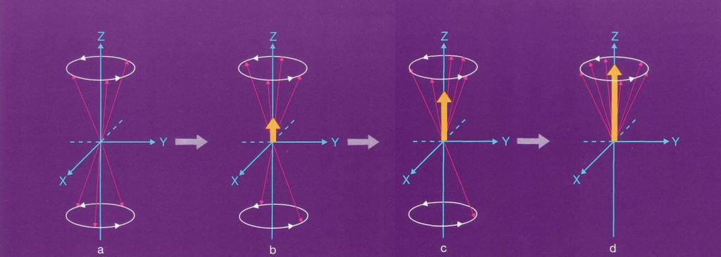

그림 17. RF 펄스가 꺼지면, 양성자들은 에너지가 높은 상태에서 낮은 상태로 돌아간다. 즉, 다시 위를 가리킨다. 이 과정이 “차례대로 하나씩” 제시되어 있다. 결과적으로 종단 자화가 증가하여 원래 값으로 다시 커진다. 단순하게 설명하기 위해, 양성자들을 동조되지 않은 상태로 그렸다. 이점은 그림 20과 26에서 더 자세히 다룰 것이다.

어떤 양성자도 손으로 걷는 일을 필요 이상으로 오래 하지 않는다 - 사람과 같다. RF 펄스에 의해 높은 에너지 상태로 고양되었던 양성자들은 낮은 에너지 상태로 돌아가서 다시 발로 걷기 시작한다.

동시에 모든 양성자가 그렇게 되는 것은 아니다. 연속적으로 하나 둘씩 원래 상태로 복귀한다. 양성자 집단의 사례가 그림 17에 제시되어 있다. 단순한 설명을 위해 양성자들을 동조되지 않은 상태로 그렸는데, 당연히 처음엔 동조된 상태에서 시작한다.

양성자들의 세차운동이 동조를 멈추는 이유와 과정은 잠시 후에 설명하기로 한다.

양성자들이 RF 펄스에서 흡수한 에너지들은 어떻게 될까?

단순히 에너지들은 소위 격자(lattice)라고 하는 주변환경에 전달된다. 따라서 이 과정을 종단 완화(longitudinal relaxation)뿐 아니라 스핀-래티스-완화(spin-lattice-relaxation)라고도 부른다.

발로 걷게 되어 다시 위쪽을 가리키게 된 양성자들은 더 이상 이전처럼 같은 수의, 위를 가리키는 양성자들이 가진 자기 벡터를 상쇄하지 않는다. 따라서 이 방향의 자화, 즉 종단 자화가 증가하여 결국 원래 값으로 복귀한다(그림 17).

시간과 종단 자화의 관계를 그려보면, 그림 18처럼 시간이 경과하면서 증가하는 곡선을 얻게 된다. 이 곡선을 T<sub>1</sub>-곡선이라 한다.

그림 18. RF 펄스가 꺼진 후부터 시간 흐름에 따라 종단 자화를 그리면, 소위 T<sub>1</sub>-곡선을 얻게 된다.

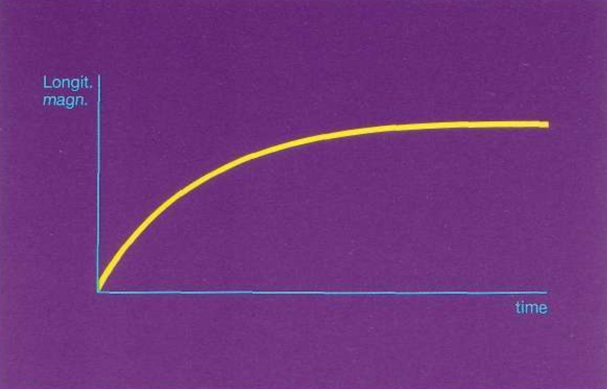

종단 자화가 회복되어 원래 값으로 돌아가는 데 걸리는 시간을 종단 완화 시간(longitudinal relaxation time), 또는 **T<sub>1</sub>**이라 한다. 그 값은 정확한 소요시간이 아니라, 얼마나 빨리 이 과정이 일어나는지를 기술하는 시간 상수(time contant)이다.

이 값은 자동차 경주에서 한 바퀴를 도는 데 필요한 시간과 같은 것이다. 그 시간을 알면, 정확한 시간이 아니라, 경주가 얼마나 오래 걸릴지 알 수 있다. 더 과학적으로 설명하자면, T<sub>1</sub>은 예컨데 방사성 붕괴(radioactive decay)를 기술하는 시간 상수와 비슷한 시간 상수이다.

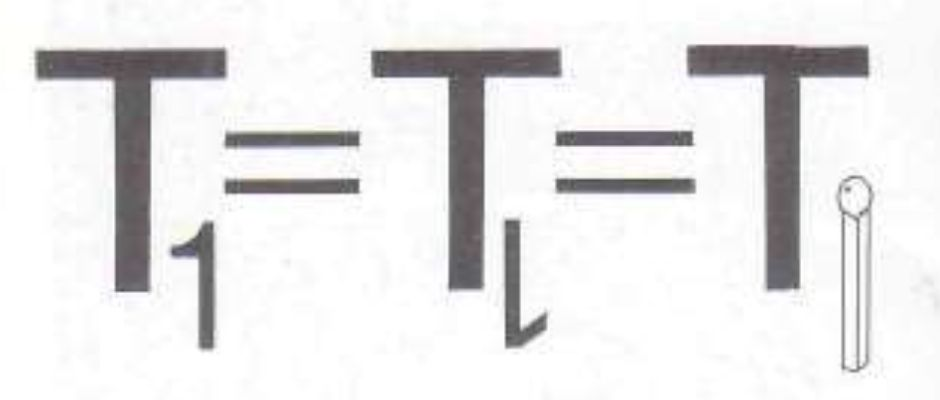

그림 19. T<sub>1</sub>은 종단 완화 시간으로서 열에너지 교환과 관련이 있다.

T<sub>1</sub>이 종단 완화 시간이라는 것을 여러분의 자판을 보면서 쉽게 기억할 수 있다(그림 19). 숫자 “1”은 “l”과 매우 비슷하니까, 스핀-래티스(“l”attice) 완화를 떠올리게 한다. 그러나 더 중요한 힌트가 그 안에 있다: “1”은 성냥과도 비슷하게 생겼다. 그리고 성냥은 이미 언급한 뭔가를 떠올리게 한다: 종단 완화는 에너지 교환과 관련이 있는데, 양성자가 낮은 에너지 상태로 복귀하면서 주변 레티스에 열에너지를 발산하는 과정이다.

# 종단 자화는 이만 하면 됐다 - 횡단 자화는 어떻게 될까?

RF 펄스가 꺼진 후, 아무도 보조를 맞추라고 시키지 않게 되면서 양성자들은 다시 동기화되지 않은 상태가 된다. 단순한 설명을 위해, 그림 20에는 모두 “위를 가리키는’ 양성자들만 사례로 제시되어 있다.

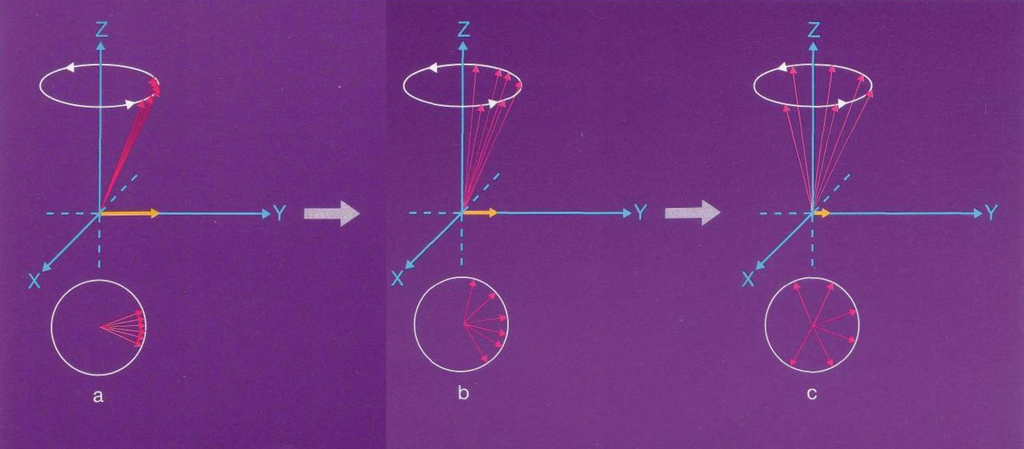

그림 20. RF 펄스가 꺼지면 양성자들은 위상 결집성(phase coherence)을 잃고 보조를 맞추지 않게 된다. (그림 아래편에 제시된 바와 같이) 위에서 내려다보면, 양성자 앙상블이 탈위상하여(dephasing) 펼쳐지는 것(fannig out)을 분명히 알 수 있다. 앙상블이 펼쳐질수록, 같은 방향을 가리키는 양성자들이 줄어들기 때문에 횡단 자화가 감소한다.

앞에서 들은 바와 같이, 양성자가 세차하는 주파수는 자장 강도에 의해 결정된다. 그런데 모든 양성자들이 같은 자장을 경험할 것같지만, 그렇지는 않다.

- 환자가 들어가는 MR 자장은 완벽하게 균일한 공간이 아니라 약간 불규칙해서 위치에 따라 세차 주파수가 다르다.
- 각각의 양성자는 인접한 핵들의 작은 자장으로부터 영향을 받는데, 이 자장들 역시 균질하게 분포된 것이 아니어 세차 주파수가 양성자마다 다를 수 있다. 이러한 내부적 자장 변이(variations)는 조직(tissue)에 따라 다르다.

따라서 RF 펄스가 꺼지면, 양성자들은 더 이상 보조를 맞추지 않는다. 양성자들은 서로 다른 세차 주파수를 가지게 되고, 곧 동조된 상태를 벗어난다.

양성자들이 얼마나 빨리 탈동조되는지 알아두는 것이 좋다. 양성자 하나(p<sub>1</sub>)가 10 MHz의 주파수로 회전 또는 세차한다고 가정하자. 즉, 이 양성자는 초당 천만번 회전한다(revolution). 비균질성(inhomogeneities)으로 인해, 인접한 양성자(p<sub>2</sub>)는 1% 강한 자장에 놓인다. 이 양성자는 1% 증가된 10.1 MHz의 세차 주파수를 갖는다. 그럴 경우, 5 마이크로초(0.000005 혹은 5 x 10<sup>-6</sup> 초) 동안, p<sub>2</sub>는 50.5번 회전하고 p<sub>1</sub>은 50번만 회전한다. 따라서 이렇게 짧은 순간에 두 양성자는 180° 탈동조되고, 해당 평면에서 서로의 자기 모멘트(magnetic moments)를 상쇄한다.

그림 21. RF 펄스가 꺼진 시점부터 시간 경과에 따른 횡단 자화 크기를 그리면, 여기 제시된 곡선을 얻게 된다. 이를 T<sub>2</sub>-곡선이라 한다.

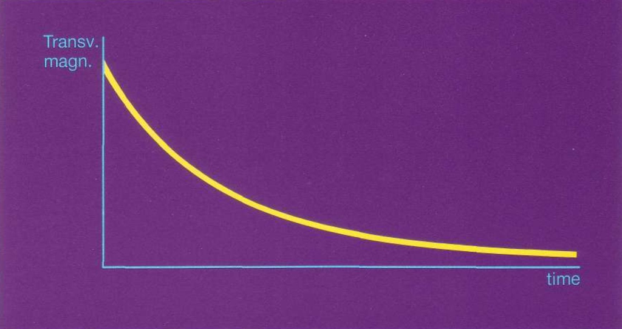

종단 자화에서 했듯이, 우리는 횡단 자화와 시간의 관계를 그릴 수 있다. 그림 21의 곡선이 그것이다. 횡단 자화는 시간이 지나면서 사라지기 때문에, 곡선은 활강한다(downhill). 아마 기대했을 것 같은데, 횡단 자화가 얼마나 빨리 소멸하고 곡선이 활강하는지를 기술하는 시간 상수도 존재한다. 이 시간 상수를 횡단 자화 시간(transversal relaxation time) **T<sub>2</sub>**라고한다. T<sub>2</sub>가 뭔지 어떻게 기억할까?

쉽다: T<sub>2</sub> = T x 2 = T T = T<sub>t</sub>,

이게 의미하는 바는 T<sub>2</sub>가 “**T t**ransversal”, 그러므로 횡단 자화의 완화를 기술한다는 것이다. 그 결과로 그림 21의 곡선을 T<sub>2</sub>-곡선이라 부른다. 횡단 자화의 또 다른 이름은 스핀-스핀 완화(spin-spin-relaxation)다. 그 기저 메커니즘이 스핀-스핀 상호작용이라는 뜻이다.

뭐가 T<sub>1</sub>-곡선이고 뭐가 T<sub>2</sub>-곡선인지 어떻게 기억할 수 있을까? 그냥 두 곡선을 이어붙이면, 스키 슬로프가 있는 산과 비슷한 모양이 된다. 여러분은 먼저 산을 오른 후(T<sub>1</sub>-곡선) 뛰어 내린다(T<sub>2</sub>-곡선; 그림 22).

그림 22. T<sub>1</sub>-과 T<sub>2</sub>-곡선을 연결하면 슬로프가 있는 산처럼 보인다. 산을 오르는 시간은 활강하거나 뛰어내리는 시간보다 오래 걸리는데, 그점을 생각하면 T<sub>1</sub>이 T<sub>2</sub>보다 보통 더 오래 걸린다는 걸 기억하기가 쉽다.

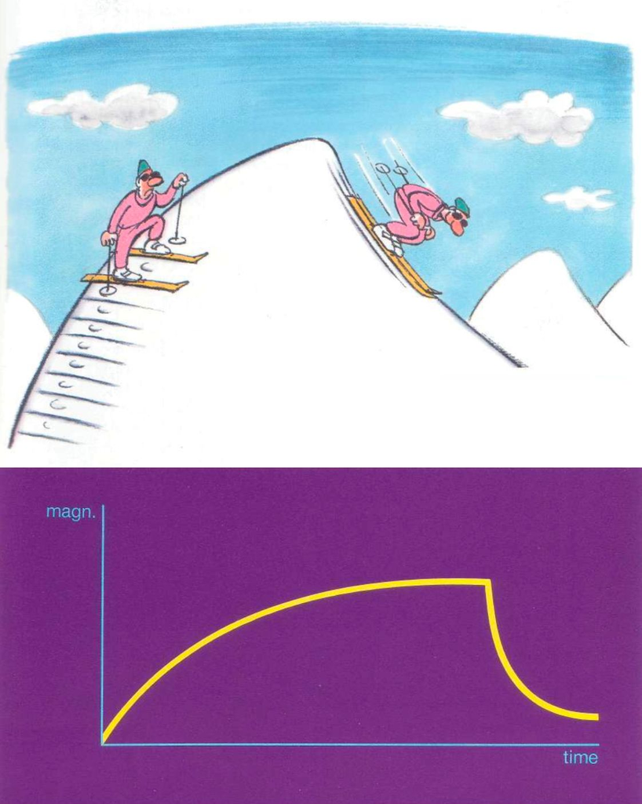

# 이제 복습할 시간이다

지금까지 배운 내용은

- 양성자는 작은 자석과 같아서
- 외부 자장에 노출되면 평행하게 혹은 역평행하게 배향(align)한다.
- 상대적으로 낮은 에너지 상태를 선호하므로, 역평행한 양성자들보다 평행한 양성자들이 약간 더 많다.
- 양성자는 운동을 하는데, 돌고 있는 팽이를 건드렸을 때 비틀거리는 모습(wobbling)과 비슷하다.
- 이런 동작을 세차운동이라 한다.
- 세차 주파수는 외부 자장의 강도에 달려있다(이 관계를 라머 공식으로 기술한다). 자장이 강할수록 세차 주파수도 높다.
- 반대 방향을 “가리키는” 양성자들은 자기 효과를 서로 상쇄한다.
- 외부 자장에 평행하게 배향하는 양성자들이 많아지면, 자기 모멘트의 총량이 외부 자장을 종단하여 배향한다.
- 양성자의 세차운동과 주파수가 같은 무선 주파수 펄스는 공명을 일으켜서 양성자에 에너지를 전달할 수 있다. 이로 인해 역평행한 양성자가 증가하고, 이들은 반대 방향의 양성자들을 더 많이 중성화 혹은 상쇄한다. 그 결과로 종단 자화가 감소한다.
- 또한 RF 펄스는 양성자들이 동기화되어 동조된 세차운동을 하게 만든다. 그로인해 새로운 자기 벡터인 횡단 자화가 생겨난다.
- RF 펄스가 꺼지면,
- 종단 자화가 다시 증가한다. 종단 완화를 시간 상수인 T<sub>1</sub> 즉, 종단 완화 시간으로 기술한다.
- 횡단 자화는 줄어들다가 사라진다. 횡단 완화를 시간 상수인 T<sub>2</sub> 즉, 횡단 완화 시간으로 기술한다. 종단 완화와 횡단 완화는 서로 다른, 독립적인 과정이므로, 우리는 각각을 따로 논의할 것이다(그림 17과 20을 보라).

이것들이 여러분이 지금까지 알고 있어야 하는 내용이다.

# 완화 시간(relaxation time)은 얼마나 긴가?

그림 22에 나오는 T<sub>1</sub>-곡선과 T<sub>2</sub>-곡선의 사례를 보자. 산꼭대기로 오를 때가 내려올 때보다 더 오래 걸린다는 점을 생각하면 이해하기가 쉽고 논리적이다. T<sub>1</sub>이 T<sub>2</sub>보다 오래 걸린다. 숫자로 말하자면; T<sub>1</sub>이 T<sub>2</sub>보다 5~10배 더 길다. 절대적인 수치를 들자면, 생물학적 조직에서 T<sub>1</sub>은 대략 300에서 2000 msec, T<sub>2</sub>는 30에서 150 msec이다.

종단 및 횡단 완화가 끝나는 시점을 정확히 알기는 어렵다. 따라서 T<sub>1</sub>과 T<sub>2</sub>는 완화가 종료되는 시간으로 정의되지 않는다. 그 대신, T<sub>1</sub>은 종단 자화가 원래 값의 대략 63%에 도달한 시점으로 정의된다. T<sub>2</sub>는 횡단 자화가 원래 값의 37%로 감소한 시점이다. 이러한 백분율은 신호 강도를 기술하는 수학 공식에서 도출되었는데(63% = 1 - 1/e; 37% = 1/e), 여기서는 더 이상 자세히 다루지 않겠다.

(그러나, 1/T<sub>1</sub>는 종단 완화 비율, 1/T<sub>2</sub>는 횡단 완화 비율로도 불린다는 점은 언급해두고 싶다.)

예전에는 완화 시간이 조직의 특성을 반영하므로 이를 측정하면 조직들을 분류할 수 있다고 믿었다. 그러나 이는 잘못된 걸로 밝혀졌는데, 시간 범위가 상당히 겹치기 때문이다. 또한 T<sub>1</sub>은 검사에 사용되는 자장의 세기에 따라 다르다(36쪽을 보라).

[figure not shown]

그림 23. 액체의 T<sub>1</sub>과 T<sub>2</sub>는 길다.

길거나 짧은 완화 시간은 무엇이고, 어떤 조직의 완화 시간이 길거나 짧을까? 그림 23을 보면 알 수 있을까? 누군가가 액체(물) 성분의 음료수를 오랫동안 마시고 있다(having a long drink). 여러분이 좋아하는 술집에 가서(인기있는 곳이라 늘 붐빈다) 천천히 마실 음료를 주문하면, 음료가 나올 때까지 꽤 오래 기다려야 한다: T<sub>1</sub>은 길다. 마침내 음료가 나오면, 그것을 마시는 데도 긴 시간이 걸리는데, 이처럼 T<sub>2</sub>도 길다. 따라서 이를 기억하자: 물이나 액체의 T<sub>1</sub>과 T<sub>2</sub>는 길다.

역주: long drink는 레모네이드, 맥주 등 긴 유리잔에 담아 나오는 찬 음료를 말한다. 맥락상, 마시는 데 시간이 걸리는 걸로 번역하였다.

이제 그림 24를 보면, 햄버거를 먹으려는 사람이 있다. 보통 햄버거는 지방을 많이 포함하므로, 여기서는 지방을 대표한다. 햄버거가 패스트푸드라서 빨리 얻을 수 있듯이, 지방은 짧은 T<sub>1</sub>을 가진다. T<sub>2</sub>는 어떨까? 패스트푸드 즉, 지방을 먹을 때는 만들 때보다 시간이 더 걸린다. 그러나 여러분이 보통 칵테일을 더 오래 마시듯이, 지방은 물보다 T<sub>2</sub>가 짧다.

물이 긴 T<sub>1</sub>과 긴 T<sub>2</sub>를 가지므로, 물을 많이 포함하는 “수성 조직”도 완화 시간이 길 거라 쉽게 예상할 수 있다. 흥미롭게도, 병리적인(pathological) 즉, 병든 조직이 종종 주변의 정상적인 조직보다 물 성분을 많이 가지고 있다.

그림 24. 액체/물과 비교할 때 지방의 T<sub>1</sub>과 T<sub>2</sub>는 짧다.

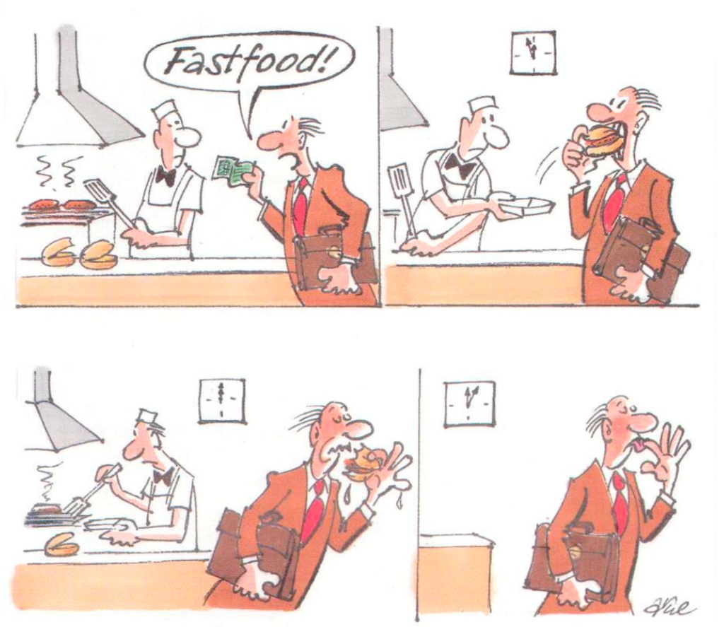

# T<sub>1</sub>은 무엇의 영향을 받을까?

사실, T<sub>1</sub>은 조직 성분, 구조, 그리고 주변환경의 영향을 받는다. 이미 읽은 바와 같이, T<sub>1</sub>-완화는 양성자들로부터 주변환경인 레티스(격자, lattice)로 전달되는 열에너지 교환과 관련이 있다. 세차하는 양성자는 자장을 가지고 끊임없이 방향을 바꾸는데, 이는 라머 주파수에 따라 끊임없이 변동한다(fluctuates). 레티스도 자체 자장을 가진다. 양성자는 레티스에 에너지를 전달함으로써 완화된다. 레티스의 자장 변화가 라머 주파수에 가까운 주파수를 가질 때 이 과정은 매우 효율적으로 완성된다.

레티스가 순수한 액체/물로 되어 있으면, 작은 물 분자들이 너무 빠르게 움직이기 때문에 양성자가 에너지를 내보내기 어렵다. 그래서 (높은 에너지 상태의) 양성자들은 에너지를 레티스에 빠르게 전달하지 못하기 때문에, 낮은 에너지 상태인 종단 배향(longitudinal alignment) 상태로 천천히 복귀하게 된다. 그러므로 종단 자화가 다시 나타나려면 시간이 오래 걸리는데, 이는 액체/물이 긴 T<sub>1</sub>을 가진다는 것을 의미한다.

중간 크기의 분자들로 구성된 레티스는(대부분의 신체 조직은 죽처럼 다양한 크기의 분자가 들어있는 액체라고 생각하면 된다), 분자가 이동하고 자장이 변동하는 주파수가 세차하는 양성자의 라머 주파수와 비슷하기 때문에, 에너지가 훨씬 빨리 이동할 수 있고 T<sub>1</sub>이 짧다.

이점은 샌드위치와 경주용 자동차 사례로도 잘 설명할 수 있다: (17쪽 참조) 차량(양성자) 한 대에서 다른 차량(레티스)으로 샌드위치를 건네는 것은 두 차량이 같은 속도로 움직일 때 쉽고 효율적이다. 속도가 다르면, 에너지 전달은 효율적이지 않게 된다.

## 지방의 T<sub>1</sub>은 왜 짧지?

지방산 끝부위의 탄소 결합은 라머 주파수에 가까운 주파수를 갖기 때문에 에너지 전달이 효율적이다.

## 강한 자장에서는 T<sub>1</sub>이 왜 더 길까?

양성자들이 강한 자장을 거슬러 정렬하려면 더 많은 에너지가 필요할 거라 쉽게 예상할 수 있다. 따라서 이런 양성자들은 레티스에 건네줄 에너지를 더 많이 가지고 있고, 에너지가 적을 때보다 전달 시간이 더 오래 걸릴 것이다. 그러나 비록 논리적으로 들리지만, 이런 설명은 틀린 것이다. 앞에서 들었던 대로, 라머 공식이 표현하는 바와 같이 세차 주파수는 자장에 의존한다. 자장이 강하면, 양성자들은 더 빨리 세차한다. 세차운동이 빨라지면, 양성자는 레티스에 에너지를 전달하는 데 어려움을 겪게 되고 자기장은 더 천천히 변동한다.

# 무엇이 T2에 영향을 끼칠까?

양성자들이 탈동조되었을 때 T<sub>2</sub>-완화가 일어는데, 이미 알고 있듯이 여기에는 두 가지 원인이 있다: 외부 자장의 비균질성(inhomogeneities), 그리고 조직 내 국소 자장의 비균질성이다(29쪽을 보라). 물 분자가 빠르게 돌아다니면, 국소 자장이 빠르게 변하면서 서로를 상쇄하게 되고 전체적으로 각 부위의 자장 차이가 사라지게 된다. 조직 내 자장 강도의 차이가 없으면, 양성자들이 오랫동안 보조를 맞추게 되므로 T<sub>2</sub>가 더 길어진다.

커다란 분자들이 섞여있는 탁한 액체의 경우에는 국소 자장의 차이가 더 크다. 분자는 클수록 빠르게 돌아다닐 수 없고, 국소 자장들도 서로를 상쇄하지 못한다. 국소 자장의 차이가 크면 세차 주파수의 차이도 커지므로, 양성자들이 더 빨리 탈동조되고, T<sub>2</sub>가 짧아진다.

이점은 다음 사례에 잘 드러난다: 웅덩이가 많은 거리에서 운전한다고 상상해보자. 천천히 운전하면(여러분이 가만히 있고 주변이 천천히 움직이는 상황과 같다), 웅덩이 하나하나를 지날 때마다 여러분은 차 안에서 위로 튀었다가 떨어진다. 주변환경의 차이(자장 변화)가 여러분에게 상당한 영향을 끼친 것이다. 그에 비해, 매우 빠르게 운전할 때(환경이 매우 빠르게 움직이는 상황과 같은데) 여러분은 더이상 개개의 웅덩이를 느낄 수 없다. 웅덩이가 중대한 영향을 끼치기 전에, 여러분은 이미 정상적인 거리 고도에 복귀한다. 웅덩이들의 효과가 상쇄되므로, 주변환경 차이(자장 강도의 차이)가 여러분에게 영향을 덜 끼치는 것이다.

이런 내용이 우리가 알고 싶어하는 것과 무슨 상관이 있을까? 이 모든 과정은 결국 여러분의 MR 영상이 어떻게 보일지에 영향을 끼친다.

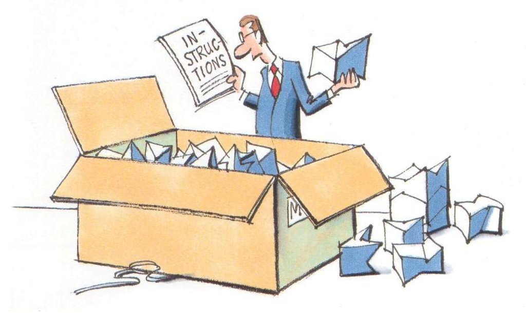

[이전 장(1장)으로] [다음 장(3장)으로]